# Bakery Turnover Prediction

Peyman Farshidfar, Gerit Imhoff, Pia Fragge, Volker Paatz

```
## x lubridate::as.difftime() masks base::as.difftime()
```

# Variablen zur Umsatzvorhersage

##Variable Monat Mittlere Umsatzdaten nach Monat und Warengruppe

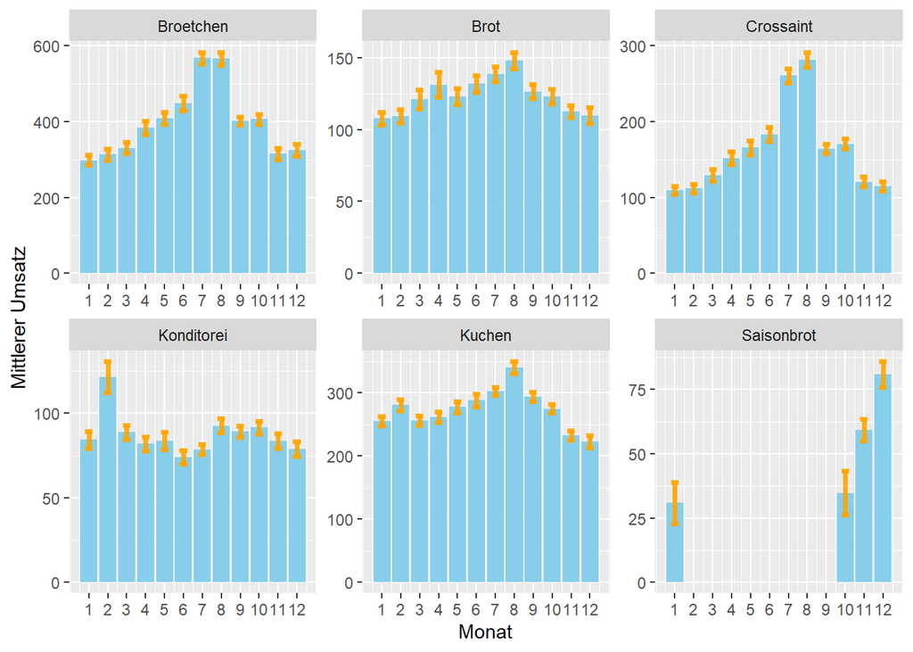

##Variable Ferien Mittlere Umsatzdaten nach Schulferien Schleswig Holstein und Warengruppe

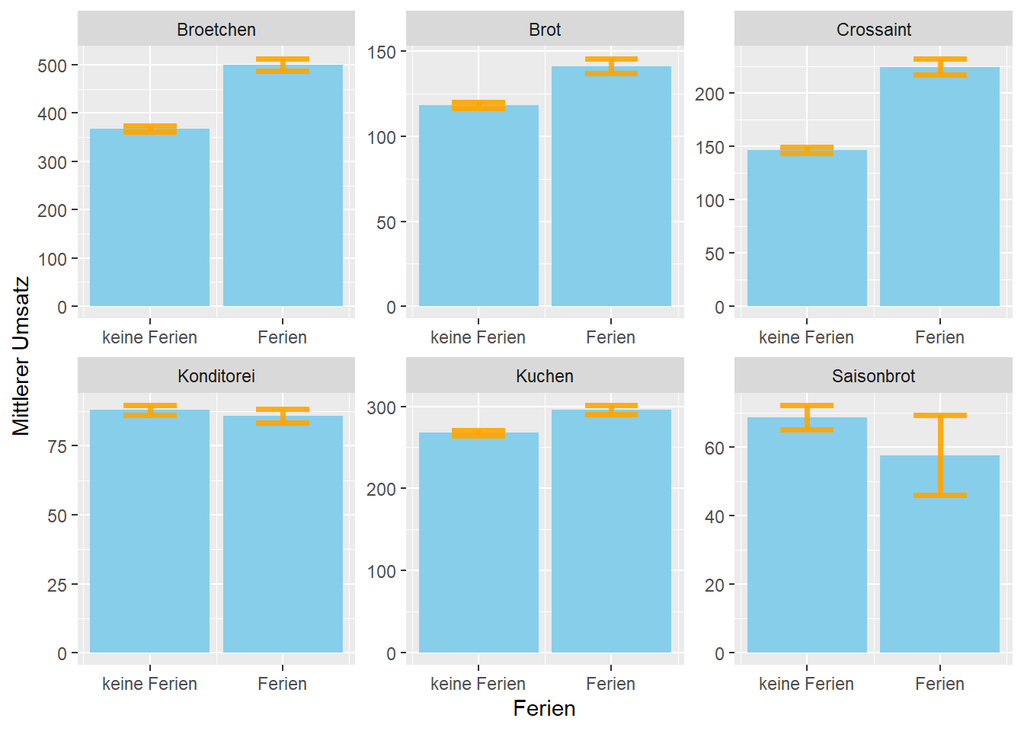

```r
## Bargraph der mittleren Umsatzdaten nach Ferien ja/nein + Konfidenzintervall 95%
mean_Ferien <- fullData %>%
  group_by(Ferien, Warengruppe) %>%
  summarise(
    n=n(),
    mean=mean(Umsatz),
    sd=sd(Umsatz)
  ) %>%
  mutate( se=sd/sqrt(n))  %>%
  mutate( ic=se * qt((1-0.05)/2 + .5, n-1))
# basic histogram
ggplot(mean_Ferien)+
  geom_bar( aes(x=Ferien, y = mean), stat="identity", fill="skyblue")+
  xlab("Ferien") + ylab("Mittlerer Umsatz")+
  scale_x_continuous(breaks = c(0, 1), labels = c('keine Ferien','Ferien'))+
  geom_errorbar( aes(x = Ferien, ymin = mean-ic, ymax = mean+ic), width=0.4, colour="orange", alpha=0.9, size=1.3)+
  facet_wrap(~Warengruppe , scales="free")
```

##Variable Feiertag Mittlere Umsatzdaten nach Feiertag Schleswig Holstein und Warengruppe

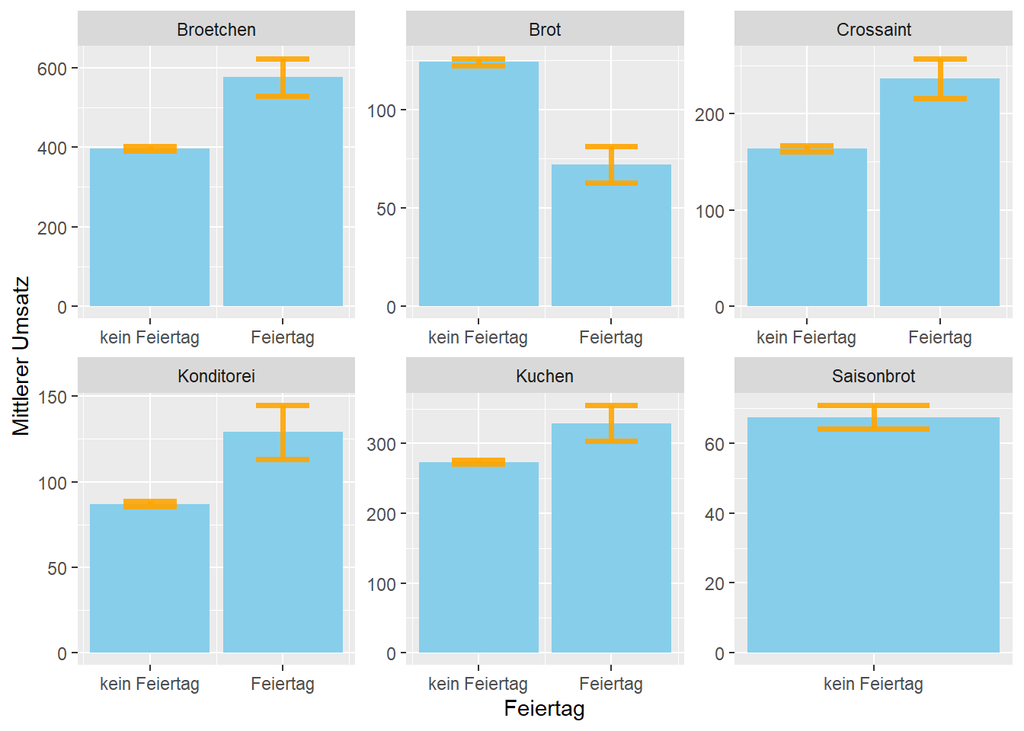

```r
## Bargraph der mittleren Umsatzdaten nach Feiertag ja/nein + Konfidenzintervall 95%
mean_Feiertag <- fullData %>%
  group_by(Feiertag, Warengruppe) %>%
  summarise(
    n=n(),
    mean=mean(Umsatz),
    sd=sd(Umsatz)
  ) %>%
  mutate( se=sd/sqrt(n))  %>%
  mutate( ic=se * qt((1-0.05)/2 + .5, n-1))
# basic histogram
ggplot(mean_Feiertag)+
  geom_bar( aes(x=Feiertag, y = mean), stat="identity", fill="skyblue")+
  xlab("Feiertag") + ylab("Mittlerer Umsatz")+
  scale_x_continuous(breaks = c(0, 1), labels = c('kein Feiertag','Feiertag'))+
  geom_errorbar( aes(x = Feiertag, ymin = mean-ic, ymax = mean+ic), width=0.4, colour="orange", alpha=0.9, size=1.3)+
  facet_wrap(~Warengruppe , scales="free")
```

##Variable Temperaturgruppen Mittlere Umsatzdaten nach Temperaturgruppen und Warengruppe

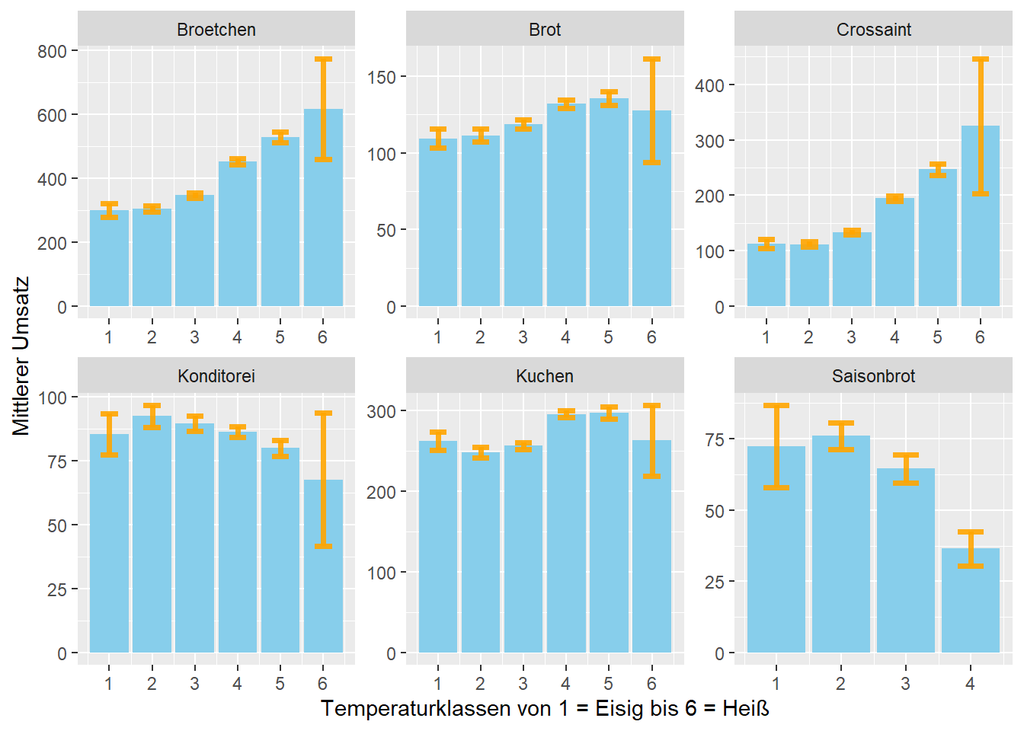

```r
## Bargraph der mittleren Umsatzdaten nach Temperaturgruppen ja/nein + Konfidenzintervall 95%
#1: Eisig
#2: Kalter Tag
#3: Vegetationstag
#4: Frühling
#5: Sommertag
#6: Heißer Tag
mean_Temperatur <- fullData %>%
  group_by(Temperatur, Warengruppe) %>%
  summarise(
    n=n(),
    mean=mean(Umsatz),
    sd=sd(Umsatz)
  ) %>%
  mutate( se=sd/sqrt(n))  %>%
  mutate( ic=se * qt((1-0.05)/2 + .5, n-1))
# basic histogram
ggplot(mean_Temperatur)+
  geom_bar( aes(x = Temperatur, y = mean), stat="identity", fill="skyblue")+
  xlab("Temperaturklassen von 1 = Eisig bis 6 = Heiß") + ylab("Mittlerer Umsatz")+
  scale_x_continuous(breaks = c(1,2,3,4,5,6))+
  geom_errorbar( aes(x = Temperatur, ymin = mean-ic, ymax = mean+ic), width=0.4, colour="orange", alpha=0.9, size=1.3)+
  facet_wrap(~Warengruppe , scales="free")
```

##Variable Niederschlagsmenge Mittlere Umsatzdaten nach Niederschlagsmenge und Warengruppe

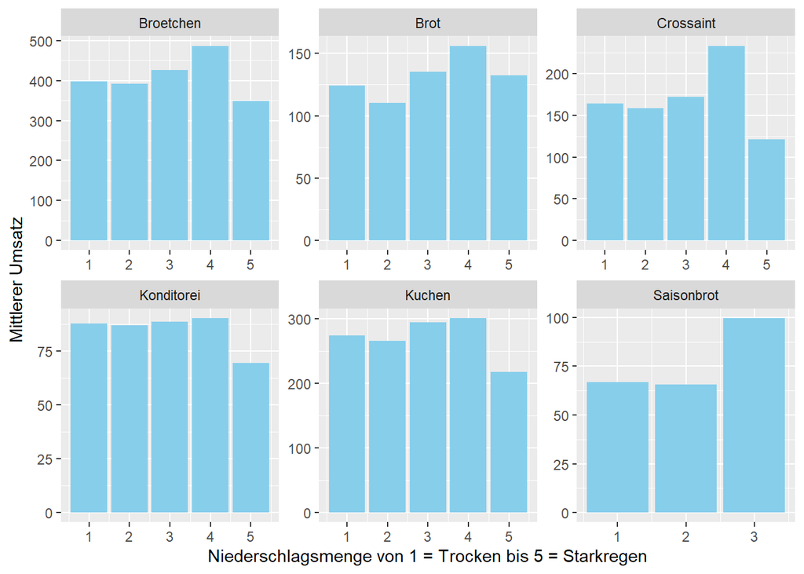

```r
## Bargraph der mittleren Umsatzdaten nach Niederschlagsmenge ja/nein
ggplot(fullData)+
  geom_bar( aes(x = Niederschlagsmenge, y = Umsatz), stat="summary", fun="mean", fill="skyblue")+
  xlab("Niederschlagsmenge von 1 = Trocken bis 5 = Starkregen") + ylab("Mittlerer Umsatz")+
  facet_wrap(~Warengruppe , scales="free")
```

##Variable Mittlerer Umsatz Variable “Mittlerer Umsatz pro Monat und Warengruppe”

[figure not shown]

```r
# Bargraph der Umsatzdaten und mittlerer Umsatz pro Monat nach Zeit für Warengruppe Brot
ggplot(fullData[fullData$Warengruppe == "Broetchen",])+
  geom_line( aes(x = Datum, y = Umsatz, colour="skyblue"), stat="summary", fun="mean")+
  geom_line( aes(x = Datum, y = Umsatz_mean, colour="red"), stat="summary", fun="mean", size=1.5)+
  xlab("Jahr") + ylab("Umsatz")+
  scale_color_discrete(name = "Umsatz", labels = c("Mittelwert pro Monat", "tatsächlich"))+
  ggtitle("Warengruppe Brot")
```

##Variable Naiv Forecast Umsatz von vor 7 Tagen pro Warengruppe, wenn Umsatz von vor 7 tagen nicht vorhenden ist, wird aktueller Umsatz verwendet

[figure not shown]

```r
# Naiv Forecast: Umsatz von vor 7 Tagen für Warengruppe Brot
ggplot(fullData[fullData$Warengruppe == "Broetchen",])+
  geom_line( aes(x = Datum, y = Umsatz, colour="skyblue"), stat="summary", fun="mean")+
  geom_line( aes(x = Datum, y = Umsatz_naiv, colour="red"), stat="summary", fun="mean")+
  xlab("Jahr") + ylab("Umsatz")+
  xlim(as.Date("2015/01/01"), as.Date("2016/12/25"))+
  scale_color_discrete(name = "Umsatz", labels = c("Umsatz von vor 7 Tagen", "aktueller Umsatz"))+
  ggtitle("Warengruppe Brot")
```

## Weitere getestete Variablen

- Sonnenscheindauer (Quelle: www.dwd.de)
- Luftfeuchtigkeit (Quelle: www.dwd.de)
- Windchillfaktor / gefühlte Temperatur
- Übernachtungszahlen in Kiel (Quelle: www.statistik-nord.de)
- Gesamtumsatz pro Monat Einzelhandel Schleswig Holstein (Quelle: www.statistik-nord.de)
- Gesamtumsatz pro Monat Gastgewerbe Schleswig Holstein (Quelle: www.statistik-nord.de)

# SVM Prediction

## Aufteilen in Training und Test Daten

## Auswählen der Features

```r
dummy_list_svm <- c("Monat", "Wochentag", "Warengruppe" , "Temperatur")
feature_list_svm <- c(dummy_list_svm, "Ferien", "Feiertage", "KielerWoche","Umsatz_mean","Umsatz_naiv")
# Bilder einer Untermenge zum Trainieren
train_dataset <- sample_frac(train_dataset, .10)
```

## Training der SVM

```r
svm_tune <- tune(svm, Umsatz ~ Warengruppe_Brot +Warengruppe_Broetchen +Warengruppe_Crossaint +Warengruppe_Konditorei + Warengruppe_Kuchen +
                   Monat_1 + Monat_2 + Monat_3 + Monat_4 + Monat_5 + Monat_6 + Monat_7 + Monat_8 + Monat_9 + Monat_10 + Monat_11 +
                   Wochentag_Montag + Wochentag_Dienstag + Wochentag_Mittwoch + Wochentag_Donnerstag + Wochentag_Freitag + Wochentag_Samstag + Ferien + Feiertag + Wochenende  + Umsatz_naiv + Umsatz_mean + KielerWoche + Temperatur_1 + Temperatur_2 + Temperatur_3 + Temperatur_4 + Temperatur_5 + Sonnenscheindauer, data=train_dataset, ranges = list(epsilon = 0.08, cost =1.5)) #seq(0.05,0.3,0.05), cost = seq(1,4,0.5)
##Auskommentieren, wenn Modell gespeichert werden soll.
#saveRDS(svm_tune, "svm_tune1.rds")
svm_tune$best.model
```

```
##
## Call:
## best.tune(method = svm, train.x = Umsatz ~ Warengruppe_Brot + Warengruppe_Broetchen +
##     Warengruppe_Crossaint + Warengruppe_Konditorei + Warengruppe_Kuchen +
##     Monat_1 + Monat_2 + Monat_3 + Monat_4 + Monat_5 + Monat_6 + Monat_7 +
##     Monat_8 + Monat_9 + Monat_10 + Monat_11 + Wochentag_Montag +
##     Wochentag_Dienstag + Wochentag_Mittwoch + Wochentag_Donnerstag +
##     Wochentag_Freitag + Wochentag_Samstag + Ferien + Feiertag + Wochenende +
##     Umsatz_naiv + Umsatz_mean + KielerWoche + Temperatur_1 + Temperatur_2 +
##     Temperatur_3 + Temperatur_4 + Temperatur_5 + Sonnenscheindauer,
##     data = train_dataset, ranges = list(epsilon = 0.08, cost = 1.5))
##
##
## Parameters:
##    SVM-Type:  eps-regression
##  SVM-Kernel:  radial
##        cost:  1.5
##       gamma:  0.02941176
##     epsilon:  0.08
##
##
## Number of Support Vectors:  708
```

## Checking the Prediction Quality

### Trainig Data

```r
# Calculating the prediction for the training data using the best model according to the grid search
pred_train <- predict(svm_tune$best.model, train_dataset)
# Calculating the prediction quality for the training data using the MAPE
mape(train_dataset$Umsatz, pred_train)
```

```
## [1] 0.1032374
```

Grafische Darstellung der Ergebnisse

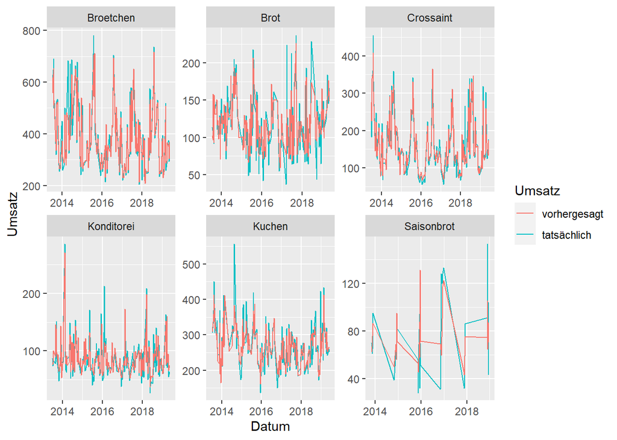

```r
# Bargraph der mittleren Umsatzdaten nach Wochentag pro Warengruppe
train_dataset$pred <- pred_train
ggplot(train_dataset)+
  geom_line( aes(x =Datum, y = Umsatz, colour="skyblue"), stat="summary", fun="mean")+
  geom_line( aes(x =Datum, y = pred, colour="orange"), stat="summary", fun="mean")+
  xlab("Datum") + ylab("Umsatz") +
  facet_wrap(~Warengruppe , scales="free")+
  scale_color_discrete(name = "Umsatz", labels = c("vorhergesagt", "tatsächlich"))
```

### Test Data

```r
# Calculating the prediction for the test data using the best model according to the grid search
pred_test <- predict(svm_tune$best.model, test_dataset)
# Calculating the prediction quality for the test data using the MAPE
mape(test_dataset$Umsatz, pred_test)
```

```
## [1] 0.1954507
```

Grafische Darstellung der Ergebnisse

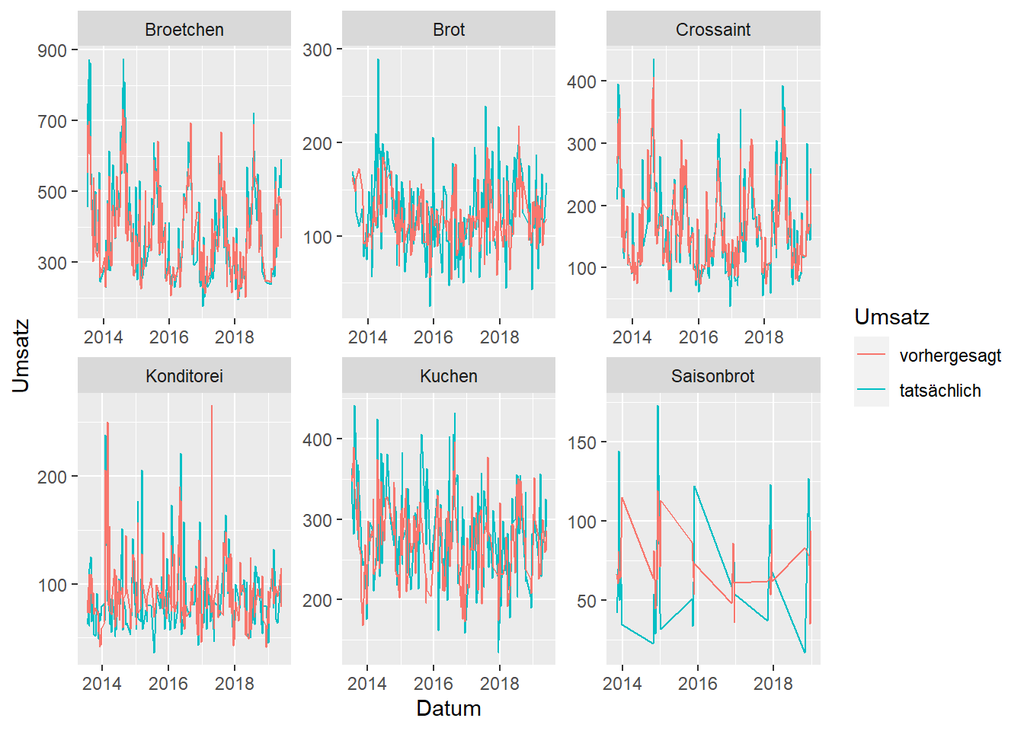

```r
# Bargraph der mittleren Umsatzdaten nach Wochentag pro Warengruppe
test_dataset$pred <- pred_test
ggplot(test_dataset)+
  geom_line( aes(x =Datum, y = Umsatz, colour="skyblue"), stat="summary", fun="mean")+
  geom_line( aes(x =Datum, y = pred, colour="orange"), stat="summary", fun="mean")+
  xlab("Datum") + ylab("Umsatz") +
  facet_wrap(~Warengruppe , scales="free")+
  scale_color_discrete(name = "Umsatz", labels = c("vorhergesagt", "tatsächlich"))
```

### New Data

```r
# Calculating the prediction for the new data (next day) using the best model according to the grid search
Umsatz_predicted <- predict(svm_tune$best.model, newData)
prediction <- data.frame(Umsatz_predicted)
prediction$Warengruppe <- newData$Warengruppe
prediction$Datum <- newData$Datum
prediction$Monat <- newData$Monat
##Da das Saisonbrot nur im Oktober, November oder Dezember verkauft wird, überprüfen, ob sich Vorhersagedatum in dem Zeitraum befindet, ansonsten Umsatz_predicted = 0 setzen
for (i in 1:nrow(prediction)){
  if ((!(prediction$Monat[i]==10 | prediction$Monat[i]==11 | prediction$Monat[i]==12)) & prediction$Warengruppe[i]=="Saisonbrot") {
    prediction$Umsatz_predicted[i] <- 0
  }
}
prediction
```

|  | Umsatz_predicted | Warengruppe | Datum | Monat |
| --- | --- | --- | --- | --- |
| 10839 | 85.74942 | Brot | 2019-06-07 | 6 |
| 10840 | 204.37929 | Broetchen | 2019-06-07 | 6 |
| 10841 | 95.09096 | Crossaint | 2019-06-07 | 6 |
| 10842 | 51.38806 | Konditorei | 2019-06-07 | 6 |
| 10843 | 0.00000 | Saisonbrot | 2019-06-07 | 6 |
| 10844 | 132.36700 | Kuchen | 2019-06-07 | 6 |

# Neuronales Netz

### Installation von Python und TensorFlow (nur einmalig nötig)

```r
#install.packages("reticulate")
library(reticulate)
# Installation von miniconda (falls nicht vorhanden)
#install_miniconda(update=TRUE)
# Anlegen einer speziellen Python Umgebung
#conda_create("r-reticulate", packages = "python=3.6")
# Installieren der Pakete in der angelegten Umgebung
#conda_install("r-reticulate", "pandas")
#conda_install("r-reticulate", "numpy")
#conda_install("r-reticulate", "tensorflow")
#conda_install("r-reticulate", "h5py")

# Verwenden der speziellen Python Umgebung die zuvor erstellt wurde
use_condaenv("r-reticulate")
```

### Aufruf des Skripts zur Datenaufbereitung

### Laden benötigter Packages

### Definition des Neuronalen Netzes

```python
# Import needed Python libraries and functions
import numpy as np
import tensorflow as tf
from tensorflow.keras.layers import Dense
from tensorflow.keras.optimizers import Adam
from tensorflow.keras.layers.experimental import preprocessing

# Create a Normalization layer and use the means and variances of the training features for the normalization
normalizer = preprocessing.Normalization()
normalizer.adapt(r.training_features.values)
# The argument "shape" for the definition of the input layer must include the number of variables (features) used for the model. To automatically calculate this number, we use the "r.training_features.keys()", which returns the list of variable names of the dataframe "training_features". Further, the function len() returns the length of this list of variable names (i.e. the number of variables in the input).
inputs = tf.keras.Input(shape=[len(r.training_features.keys())])
# Normalization layer
x = normalizer(inputs)
# 1st hidden layer
x = Dense(105, activation='relu')(x)
# 2nd hidden layer
x = Dense(4, activation='relu')(x)
# Output layer
output = tf.keras.layers.Dense(1)(x)
# Model definition
model = tf.keras.Model(inputs, output)
# Ausgabe einer Zusammenfassung zur Form des Modells, das geschaetzt wird (nicht notwendig)
model.summary()
```

```
## Model: "functional_1"
## _________________________________________________________________
## Layer (type)                 Output Shape              Param #
## =================================================================
## input_1 (InputLayer)         [(None, 38)]              0
## _________________________________________________________________
## normalization (Normalization (None, 38)                77
## _________________________________________________________________
## dense (Dense)                (None, 105)               4095
## _________________________________________________________________
## dense_1 (Dense)              (None, 4)                 424
## _________________________________________________________________
## dense_2 (Dense)              (None, 1)                 5
## =================================================================
## Total params: 4,601
## Trainable params: 4,524
## Non-trainable params: 77
## _________________________________________________________________
```

### Schätzung des neuronalen Netzes

```python
# Definition der Kosten-(Loss-)Funktion und der Optimierungsfunktion mit seinen Hyperparametern
model.compile(loss="mse", optimizer=Adam(lr=0.001))
# Schaetzung des Modells
history = model.fit(r.training_features, r.training_labels, epochs=50,
                    validation_data = (r.validation_features, r.validation_labels), verbose=0)
# Ggf. Speichern des geschaetzten Modells
model.save("python_model.h5")
```

### Auswertung der Modelloptimierung

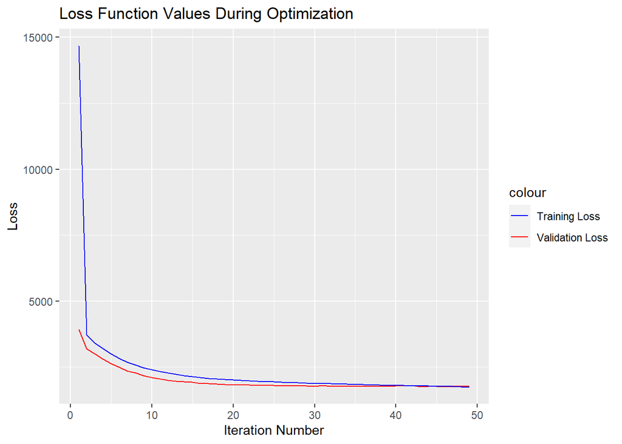

```r
# Grafische Ausgabe der Modelloptimierung
# create data
data <- data.frame(val_loss = unlist(py$history$history$val_loss),
                  loss = unlist(py$history$history$loss))
# Plot
ggplot(data[-1,]) +
  geom_line( aes(x=1:length(val_loss), y=val_loss, colour = "Validation Loss" )) +
  geom_line( aes(x=1:length(loss), y=loss, colour = "Training Loss" )) +
  scale_colour_manual( values = c("Training Loss"="blue", "Validation Loss"="red") ) +
  labs(title="Loss Function Values During Optimization") +
  xlab("Iteration Number") +
  ylab("Loss")
```

### (Ggf.) Laden eines gespeicherten Neuronalen Netzes

```python
model = tf.keras.models.load_model("python_model.h5")
```

### Auswertung der Schätzergebnisse

```r
# Schätzung der (normierten) Preise für die Trainings- und Testdaten
training_predictions <- py$model$predict(training_features)
validation_predictions <- py$model$predict(validation_features)
# Vergleich der Gütekriterien für die Traingings- und Testdaten


cat(paste0("MAPE on the Training Data:\t", format(mape(training_labels[[1]], training_predictions)*100, digits=3, nsmall=2)))
```

```
## MAPE on the Training Data:   16.90
```

```r
cat(paste0("\nMAPE on the Validation Data:\t", format(mape(validation_labels[[1]], validation_predictions)*100, digits=3, nsmall=2)))
```

```
##
## MAPE on the Validation Data: 18.47
```

### Grafischer vergleich der vorhergesagten und der tatsächlichen Preise für die Trainings- und Testdaten

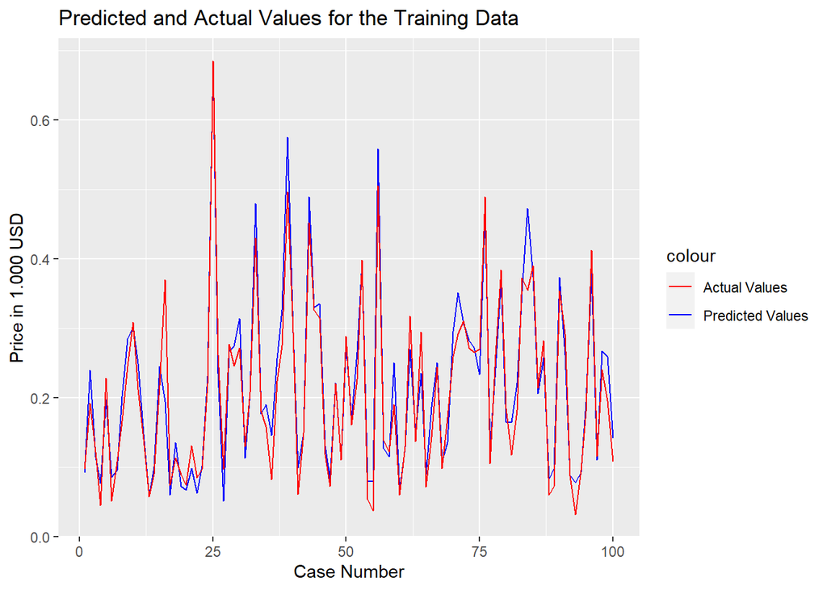

```r
# Zusammenstellung der Daten für die Plots
data_train <- data.frame(prediction = training_predictions/1000, actual = training_labels[[1]]/1000)
data_test <- data.frame(prediction = validation_predictions/1000, actual = validation_labels[[1]]/1000)
# Plot der Ergebnisse der Trainingsdaten
ggplot(data_train[1:100,]) +
  geom_line( aes(x=1:length(prediction), y=prediction, colour = "Predicted Values" )) +
  geom_line( aes(x=1:length(actual), y=actual, colour = "Actual Values" )) +
  scale_colour_manual( values = c("Predicted Values"="blue", "Actual Values"="red") ) +
  labs(title="Predicted and Actual Values for the Training Data") +
  xlab("Case Number") +
  ylab("Price in 1.000 USD")
```

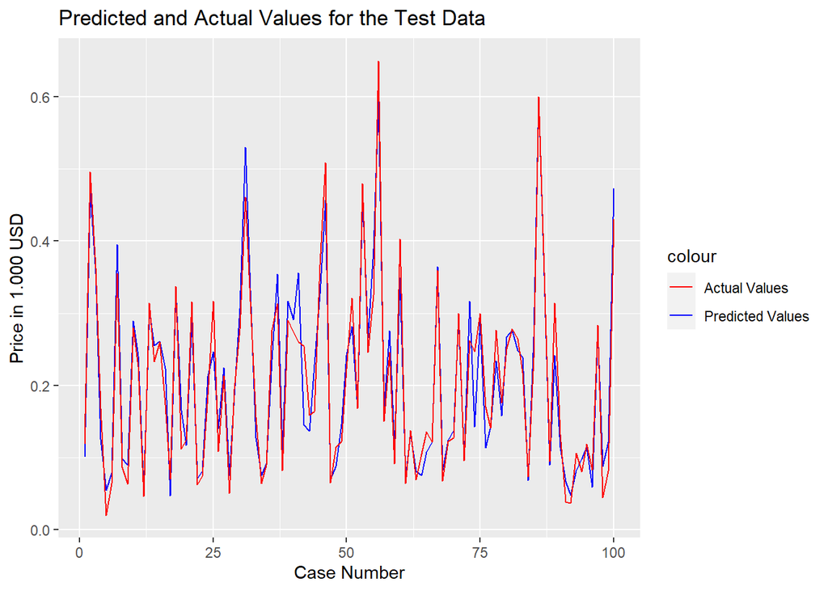

```r
# Plot der Ergebnisse der Validierungsdaten
ggplot(data_test[1:100,]) +
  geom_line( aes(x=1:length(prediction), y=prediction, colour = "Predicted Values" )) +
  geom_line( aes(x=1:length(actual), y=actual, colour = "Actual Values" )) +
  scale_colour_manual( values = c("Predicted Values"="blue", "Actual Values"="red") ) +
  labs(title="Predicted and Actual Values for the Test Data") +
  xlab("Case Number") +
  ylab("Price in 1.000 USD")
```

### Vorhersage für einen einzelnen Fall

```r
cat(paste0("Vorhergesagter Umsatz:\t", round(validation_predictions[100])))
```

```
## Vorhergesagter Umsatz:   473
```

```r
cat(paste0("\nTatsächlicher Umsatz:\t", validation_labels[[1]][100]))
```

```
##
## Tatsächlicher Umsatz:    430
```

### Vorbereiten der Daten zur Vorhersage

```r
#Sortieren nach ID
newData <- newData[order(newData$ID),]
colnamesPred <- colnames(validation_features)
validation_features2 <- newData[colnamesPred]

validation_features2
```

| Ferien | Feiertag | Wochenende | KielerWoche | Bewoelkung_0 | Bewoelkung_1 | Bewoelkung_2 | Bewoelkung_3 | Bewoelkung_4 | Bewoelkung_5 | Bewoelkung_6 | Bewoelkung_7 | Bewoelkung_8 | Monat_1 | Monat_2 | Monat_3 | Monat_4 | Monat_5 | Monat_6 | Monat_7 | Monat_8 | Monat_9 | Monat_10 | Monat_11 | Monat_12 | Wochentag_Dienstag | Wochentag_Donnerstag | Wochentag_Freitag | Wochentag_Mittwoch | Wochentag_Montag | … |
| --- | --- | --- | --- | --- | --- | --- | --- | --- | --- | --- | --- | --- | --- | --- | --- | --- | --- | --- | --- | --- | --- | --- | --- | --- | --- | --- | --- | --- | --- | --- |
| 0 | 0 | 0 | 0 | 0 | 1 | 0 | 0 | 0 | 0 | 0 | 0 | 0 | 0 | 0 | 0 | 0 | 0 | 1 | 0 | 0 | 0 | 0 | 0 | 0 | 0 | 0 | 1 | 0 | 0 | … |
| 0 | 0 | 0 | 0 | 0 | 1 | 0 | 0 | 0 | 0 | 0 | 0 | 0 | 0 | 0 | 0 | 0 | 0 | 1 | 0 | 0 | 0 | 0 | 0 | 0 | 0 | 0 | 1 | 0 | 0 | … |
| 0 | 0 | 0 | 0 | 0 | 1 | 0 | 0 | 0 | 0 | 0 | 0 | 0 | 0 | 0 | 0 | 0 | 0 | 1 | 0 | 0 | 0 | 0 | 0 | 0 | 0 | 0 | 1 | 0 | 0 | … |
| 0 | 0 | 0 | 0 | 0 | 1 | 0 | 0 | 0 | 0 | 0 | 0 | 0 | 0 | 0 | 0 | 0 | 0 | 1 | 0 | 0 | 0 | 0 | 0 | 0 | 0 | 0 | 1 | 0 | 0 | … |
| 0 | 0 | 0 | 0 | 0 | 1 | 0 | 0 | 0 | 0 | 0 | 0 | 0 | 0 | 0 | 0 | 0 | 0 | 1 | 0 | 0 | 0 | 0 | 0 | 0 | 0 | 0 | 1 | 0 | 0 | … |
| 0 | 0 | 0 | 0 | 0 | 1 | 0 | 0 | 0 | 0 | 0 | 0 | 0 | 0 | 0 | 0 | 0 | 0 | 1 | 0 | 0 | 0 | 0 | 0 | 0 | 0 | 0 | 1 | 0 | 0 | … |

```r
#colnamesPred2 <- colnames(training_features)
#training_features2 <- newData[colnamesPred2]
#training_features2
```

### Auswertung der Schätzergebnisse mit Warengruppe 6

```r
# Schätzung der (normierten) Preise für die Trainings- und Testdaten
Umsatz_predicted <- py$model$predict(validation_features2)

prediction <- data.frame(Umsatz_predicted)
prediction$Warengruppe <- newData$Warengruppe
prediction$Datum <- newData$Datum
prediction$Monat <- newData$Monat




unlink("nne_prediction_1.csv")
    writecsvData <- prediction
    writecsvData <- cbind(ID = 1:nrow(writecsvData), writecsvData)

    write.csv(writecsvData,"nne_prediction_1.csv", append = FALSE, quote = TRUE, sep = ",",
              eol = "\n", na = "NA", dec = ".", row.names = FALSE,
              col.names = TRUE, qmethod = c("escape", "double"),
              fileEncoding = "")
prediction
```

| Umsatz_predicted | Warengruppe | Datum | Monat |
| --- | --- | --- | --- |
| 134.85550 | Brot | 2019-06-07 | 6 |
| 375.71600 | Broetchen | 2019-06-07 | 6 |
| 153.21002 | Crossaint | 2019-06-07 | 6 |
| 60.29716 | Konditorei | 2019-06-07 | 6 |
| 64.83141 | Saisonbrot | 2019-06-07 | 6 |
| 278.86511 | Kuchen | 2019-06-07 | 6 |

### Grafische Darstellung der Vorhersage mit Warengruppe 6

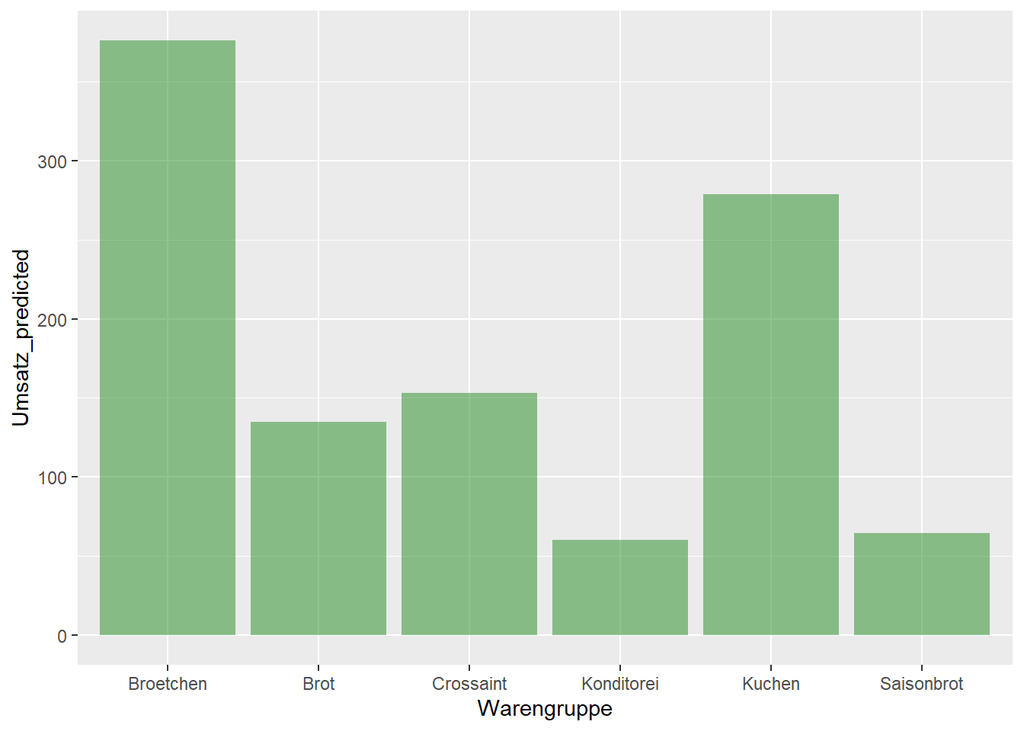

```r
ggplot(prediction) +
  geom_bar( aes(x=Warengruppe, y=Umsatz_predicted), stat="identity", fill="forestgreen", alpha=0.5)
```

### Auswertung der Schätzergebnisse ohne Warengruppe 6

```r
##Da das Saisonbrot nur im Oktober, November oder Dezember verkauft wird, überprüfen, ob sich Vorhersagedatum in dem Zeitraum befindet, ansonsten Umsatz_predicted = 0 setzen
for (i in 1:nrow(prediction)){
  if ((!(prediction$Monat[i]==10 | prediction$Monat[i]==11 | prediction$Monat[i]==12)) & prediction$Warengruppe[i]=="Saisonbrot") {
    prediction$Umsatz_predicted[i] <- 0
  }
}

unlink("nne_prediction_2.csv")
    writecsvData <- prediction
    writecsvData <- cbind(ID = 1:nrow(writecsvData), writecsvData)

    write.csv(writecsvData,"nne_prediction_2.csv", append = FALSE, quote = TRUE, sep = ",",
              eol = "\n", na = "NA", dec = ".", row.names = FALSE,
              col.names = TRUE, qmethod = c("escape", "double"),
              fileEncoding = "")
prediction
```

| Umsatz_predicted | Warengruppe | Datum | Monat |
| --- | --- | --- | --- |
| 134.85550 | Brot | 2019-06-07 | 6 |
| 375.71600 | Broetchen | 2019-06-07 | 6 |
| 153.21002 | Crossaint | 2019-06-07 | 6 |
| 60.29716 | Konditorei | 2019-06-07 | 6 |
| 0.00000 | Saisonbrot | 2019-06-07 | 6 |
| 278.86511 | Kuchen | 2019-06-07 | 6 |

### Grafische Darstellung der Vorhersage ohne Warengruppe 6

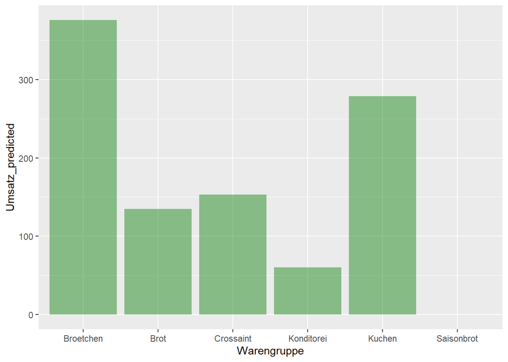

```r
ggplot(prediction) +
  geom_bar( aes(x=Warengruppe, y=Umsatz_predicted), stat="identity", fill="forestgreen", alpha=0.5)
```

### Grafische Darstellung der beiden Vorhersage-Modelle

```r
nne_prediction <- read_csv("nne_prediction_2.csv")
svm_prediction <- read_csv("svm_prediction_2.csv")
```

```r
plot_prediction <- svm_prediction
plot_prediction = rename(plot_prediction, Umsatz_SVM = Umsatz_predicted)

plot_prediction$Umsatz_NNE <- nne_prediction$Umsatz_predicted
plot_prediction$Umsatz_NNE
```

```
## [1] 134.85550 375.71600 153.21002  60.29716   0.00000 278.86511
```

```r
str(plot_prediction)
```

```
## spec_tbl_df [6 x 6] (S3: spec_tbl_df/tbl_df/tbl/data.frame)
##  $ ID         : num [1:6] 1 2 3 4 5 6
##  $ Umsatz_SVM : num [1:6] 98.4 230.4 120.3 76.7 0 ...
##  $ Warengruppe: chr [1:6] "Brot" "Broetchen" "Crossaint" "Konditorei" ...
##  $ Datum      : Date[1:6], format: "2019-06-07" "2019-06-07" ...
##  $ Monat      : num [1:6] 6 6 6 6 6 6
##  $ Umsatz_NNE : num [1:6] 134.9 375.7 153.2 60.3 0 ...
##  - attr(*, "spec")=
##   .. cols(
##   ..   ID = col_double(),
##   ..   Umsatz_predicted = col_double(),
##   ..   Warengruppe = col_character(),
##   ..   Datum = col_date(format = ""),
##   ..   Monat = col_double()
##   .. )
```

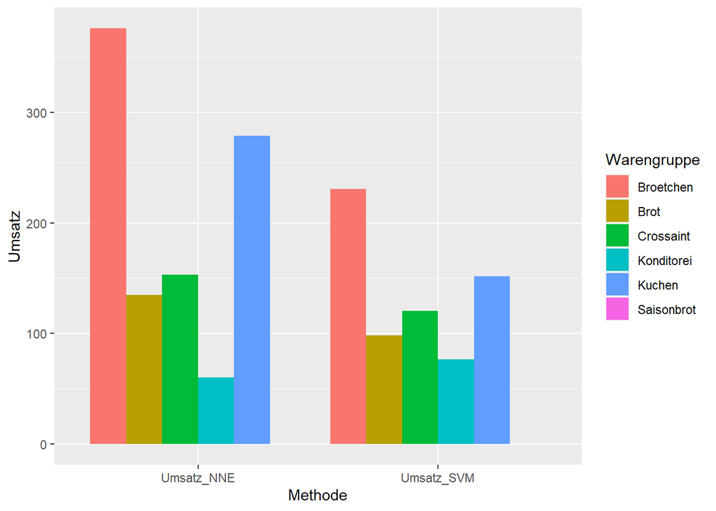

```r
df1 <- data.frame(Warengruppe=rep(svm_prediction$Warengruppe),
                 Methode=rep('Umsatz_SVM'),
                 Umsatz=svm_prediction$Umsatz_predicted)

df2 <- data.frame(Warengruppe=rep(nne_prediction$Warengruppe),
                 Methode=rep('Umsatz_NNE'),
                 Umsatz=nne_prediction$Umsatz_predicted)

dft <- rbind(df1,df2)


dft <- dft[order(dft$Warengruppe),]

ggplot(dft, aes(fill=Warengruppe, y=Umsatz, x=Methode)) +
  geom_bar(position='dodge', stat='identity')
```

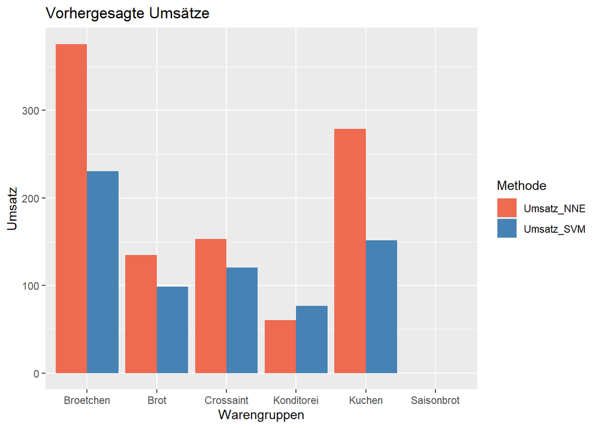

```r
ggplot(dft, aes(fill=Methode, y=Umsatz, x=Warengruppe)) +
  geom_bar(position='dodge', stat='identity') +
  ggtitle('Vorhergesagte Umsätze') +
  xlab('Warengruppen') +
  ylab('Umsatz') +
  scale_fill_manual('Methode', values=c('coral2','steelblue'))
```

### Grafische Darstellung der beiden Vorhersage-Modelle

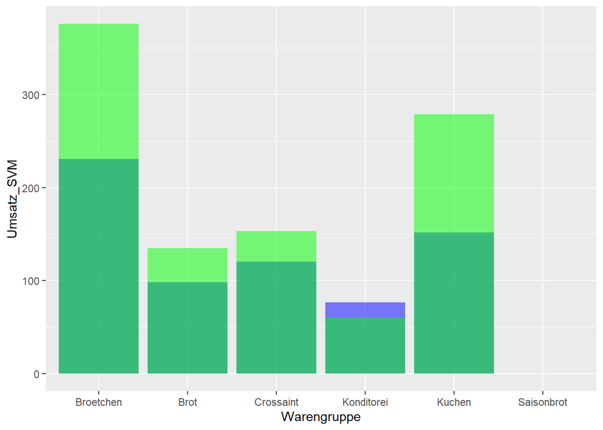

```r
ggplot(plot_prediction) +
  geom_bar( aes(x=Warengruppe, y=Umsatz_SVM), stat="identity", fill="blue", alpha=0.5) +
  geom_bar( aes(x=Warengruppe, y=Umsatz_NNE), stat="identity", fill="green", alpha=0.5)
```